# George Proof of Concept

Related resources:

1. [CG - Exact Gaussian Processes on a Million Data Points](https://arxiv.org/abs/1903.08114): Key insight is to use CG to find the *exact* solution to $Ax = b$ instead of finding the $A^{-1}$ and the other terms ($det(A)$) can be approximated with Lanczos.
2. [HOLDR - George](https://george.readthedocs.io/en/latest/): Author implementation of the George-HOLDR method.
3. [HOLDR - Fast Direct Methods for Gaussian Processes](https://arxiv.org/pdf/1403.6015.pdf): Key insight is to use hierarchical matrices to perform the $LL^T$ decomposition.

This is a proof of concept for optimizing the accuracy of the George-HOLDR method using using hierarchical matrices.

The major advantage of this method when compared to other state of the art methods is that the George-HOLDR method is very fast. The below is a comparison of the George-HOLDR method against CG methods on both GPU and CPU, other common GP libraries are also compared below.

[figure not shown]

The major disadvantage of this method is that there are accuracy problems. As the kernel matrix deviates away from the hierarchical matrix assumption, the accuracy is greatly affected. The required hierarchical matrix assumption is of the following pattern:

[figure not shown]

The key insight to the mechanism is that the the closer the kernel matrix is to a hierarchical matrix, the better the accuracy. Since George-HOLDR is fast, we want to pay some compute cost to massage the kernel matrix into fitting more of the hierarchical matrix assumption.

A simple technique without context, to achieve this is to do Gaussian Elimination, ie. row/column operations to massage the kernel matrix into a hierarchical matrix. However, in our case, we can swap the sequence of points in $X$ to influence $K=\kappa(X,X)$. Note that swapping the sequence of points will not change the solution. In this manner, we can leverage on the known $\kappa$ and also $X$ to rearrage the points in $X$ to allow $K$ to resemble more of a hierarchical matrix.

In this proof of concept, we will show that when $K$ fits the hierarchical matrix assumption then we will achieve a good accuracy of the log likelihood. We find the matrix $K$ for which will achieve a good accuracy for log likelihood. We will use a traditional method to compute the accurate log likelihood $\ell^*$ and attempt to use this log likelihood to find a good $X_i$ which is a rearragement of original $X$.

We formulate the problem as a optimization problem and use Genetic Algorithm to find $X_i$:

- Mutation operation: Swapping of 2 points inside $X_i$
- Fitness score: Absolute difference of the accurate log likelihood and the current log likelihood $|\ell^*-\ell_i|$ Genetic Algorithm is chosen as the solution $X_i$ is incrementally closer to the better solution than $X_{i-1}$ and the only operation that can be performed is to swap rows, along with a clear metric to be used.

Here we setup the synthetic function $y=\sin(x)$ with 200 data points. Then, we compute the accurate log likelihood - $\ell^*$ of the $X$.

```python
import numpy as np
import george

np.random.seed(0)

x = np.random.uniform(0, 10, 500000)
noise = 0.3
sigma_err = noise ** 2
yerr = noise * np.ones_like(x)
y = np.sin(x)
var_y = np.var(y)
N = 200

import george
from george import kernels
kernel = var_y * kernels.ExpSquaredKernel(1.0)

gp_basic = george.GP(kernel)
gp_basic.compute(x[:N], yerr[:N])
desired_accuracy = gp_basic.log_likelihood(y[:N])
print(desired_accuracy)
```

```
31.344534039948208
```

Naively, we compute the loglikelihood $\ell_0$ of $X$ using George-HODLR. As expected, it deviates substantially from $\ell^*$.

```python
arg_idx = np.argsort(x[:N])
_x = x[:N]
_yerr = yerr[:N]
_y = y[:N]

gp_hodlr = george.GP(kernel, solver=george.HODLRSolver)
gp_hodlr.compute(_x, _yerr)
print(gp_hodlr.log_likelihood(_y))
```

```
27.999925428623843
```

Now we use Genetic Algorithm to optimize the sequence in $X$, we use $10000$ iterations with a population of $10$. The final $\ell_{10000}$ is printed; as expected it is very close to $\ell^*$.

```python
# Simple optimization to find the best
def eval_fitness(idx):
    _gp_hodlr = george.GP(kernel, solver=george.HODLRSolver)
    _gp_hodlr.compute(_x[idx], _yerr[idx])
    fitness_val = np.abs(_gp_hodlr.log_likelihood(_y[idx]) - desired_accuracy)
    return fitness_val

opt_N = 10000
init_N = 10
indices = np.array(range(len(arg_idx)))
cand_pop = [  ]
for i in range(init_N):
    candidate_arg_idx = arg_idx.copy()
    idx = np.random.choice(indices, size=2, replace=False)
    candidate_arg_idx[idx] = np.flip(candidate_arg_idx[idx])
    cand_pop.append((candidate_arg_idx, eval_fitness(candidate_arg_idx)))
for i in range(opt_N):
    new_cand_pop = []
    for current_cand_pop in cand_pop:
        curr_candidate_arg_idx, old_fitness_val = current_cand_pop
        idx = np.random.choice(indices, size=2, replace=False)
        curr_candidate_arg_idx[idx] = np.flip(curr_candidate_arg_idx[idx])
        new_fitness_val = eval_fitness(curr_candidate_arg_idx)
        if new_fitness_val < old_fitness_val:
            new_cand_pop.append((curr_candidate_arg_idx, new_fitness_val))
        else:
            curr_candidate_arg_idx[idx] = np.flip(curr_candidate_arg_idx[idx])
            new_cand_pop.append((curr_candidate_arg_idx, old_fitness_val))
    cand_pop = new_cand_pop

arg_idx,_ = min(cand_pop, key=lambda x:x[1])

_gp_hodlr = george.GP(kernel, solver=george.HODLRSolver)
_gp_hodlr.compute(_x[arg_idx], _yerr[arg_idx])
print(_gp_hodlr.log_likelihood(_y[arg_idx]))
```

```
31.344533898617545
```

Here, we show that the sequence in $X$ does not impact the solution. We take the sequence found in the genetic algorithm, $X_{10000}$ and use it on a regular GP to find the log likelihood; as expected the likelihood stays the same.

```python
__gp_hodlr = george.GP(kernel)
__gp_hodlr.compute(_x[arg_idx], _yerr[arg_idx])
print(__gp_hodlr.log_likelihood(_y[arg_idx]))
```

```
31.344534039948236
```

Here, we double check the log likelihood using different GP library, SKLearn. The log likelihood is the same.

```python
import sklearn
from sklearn.gaussian_process.kernels import RBF, WhiteKernel
from sklearn.gaussian_process import GaussianProcessRegressor

kernel_skl = var_y * RBF(length_scale=1.0)
#print(kernel_skl(x[:10, None], x[:10, None]))
gp_skl = GaussianProcessRegressor(kernel_skl,
                                  alpha=sigma_err,
                                  optimizer=None,
                                  copy_X_train=False)
matrix_val = kernel_skl(x[:N, None])
gp_skl.fit(x[:N, None], y[:N])
print(gp_skl.log_marginal_likelihood(kernel_skl.theta))
```

```
31.344534041255827
```

Now, we show the kernel matrix $\kappa(X_{10000},X_{10000})$ that is found by the Genetic Algorithm. As expected it resembles a hierarchical matrix.

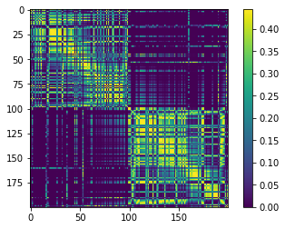

```python
%matplotlib inline
import numpy as np
import matplotlib.pyplot as plt

plt.imshow(_gp_hodlr.get_matrix(_x[arg_idx]))
plt.colorbar()
plt.show()
```

This is the original kernel matrix $\kappa(X,X)$.

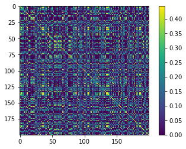

```python
plt.imshow(matrix_val)
plt.colorbar()
plt.show()
```

Conclusion, this concept works. We need to find an appropriate norm to use as a metric, as discussed:

1. Nucleus norm
2. Others - https://en.wikipedia.org/wiki/Matrix_norm

We can do some preprocessing using:

1. K-Clustering
2. KD Tree